# Chapter 10 - Linear regression with multiple predictors

# Adding predictors to a model

## Starting with a binary predictor

We start by modeling the children’s test scores given an indicator for wether the mother graduated from high school:

```r
load("KidIQ/data/kidiq.rda")

fit.1 <- stan_glm(kid_score ~ mom_hs, data = kidiq)
print(fit.1)
```

```
stan_glm
 family:       gaussian [identity]
 formula:      kid_score ~ mom_hs
 observations: 434
 predictors:   2
------
            Median MAD_SD
(Intercept) 77.5    2.0
mom_hs      11.8    2.3

Auxiliary parameter(s):
      Median MAD_SD
sigma 19.9    0.7

------
* For help interpreting the printed output see ?print.stanreg
* For info on the priors used see ?prior_summary.stanreg
```

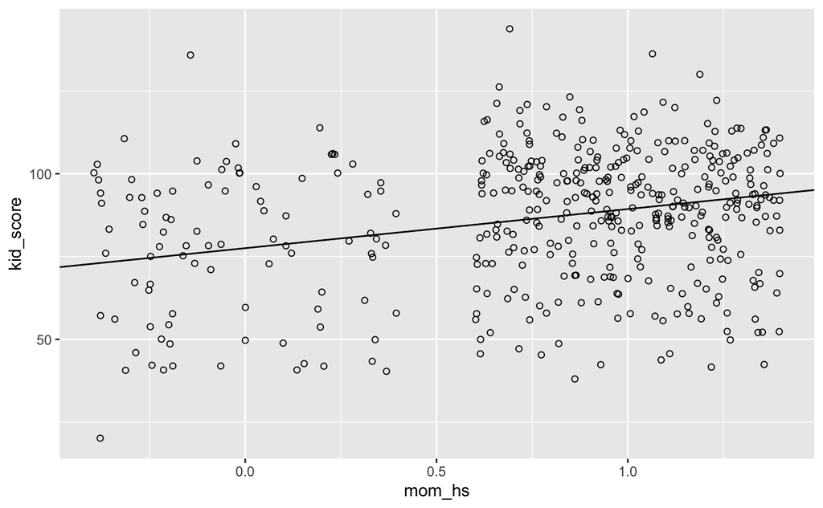

```r
ggplot(data = kidiq, aes(x = mom_hs, y = kid_score)) +
  geom_point(position = position_jitter(), shape = 1) +
  geom_abline(intercept = coef(fit.1)[1], slope = coef(fit.1)[2])
```

## A single continuous predictor

```r
print(fit.2)
```

```
stan_glm
 family:       gaussian [identity]
 formula:      kid_score ~ mom_iq
 observations: 434
 predictors:   2
------
            Median MAD_SD
(Intercept) 26.1    5.8
mom_iq       0.6    0.1

Auxiliary parameter(s):
      Median MAD_SD
sigma 18.3    0.6

------
* For help interpreting the printed output see ?print.stanreg
* For info on the priors used see ?prior_summary.stanreg
```

## Including both predictors

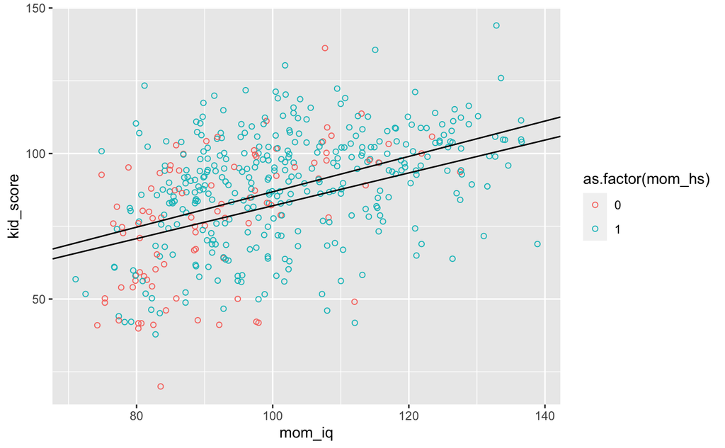

## Understanding the fitted model

- The intercept: if a child had a mother with an IQ of 0 and did not complete HS, then we would predict this child’s test score to be 26
- The coefficient of maternal HS completion: comparing children whose mothers have the same IQ, but who differed in whether they completed HS, the model predicts an expected difference of 6 in their test scores
- The coefficient of maternal IQ: comparing children whose mothers have the same level of HS but who differed by 1 IQ point, the model predicts an expected diffference of 0.6 points in the child’s test score

# Interpreting regression coefficients

## It’s not always possible to change one predictor while holding all others constant

## Counterfactual and predictive interpretations

- the predictive interpretation: considers who the outcome variable differs, on average, when comparing two groups of items that differ by 1 in the relevant predictor while being identical in all the other predictors
- the counterfactual interpretation: expressed in terms of changes within individuals, rather than comparisons between individuals. Here the coefficient is the expected change in $y$ caused by adding 1 to the relevant predictor, while leaving all the other predictors in the model unchanged.
- regression only tells us about comparisons between units, not about changes within units

# Interactions

```r
print(fit.4)
```

```
stan_glm
 family:       gaussian [identity]
 formula:      kid_score ~ mom_hs * mom_iq
 observations: 434
 predictors:   4
------
              Median MAD_SD
(Intercept)   -7.3   13.5
mom_hs        46.1   15.1
mom_iq         0.9    0.1
mom_hs:mom_iq -0.4    0.2

Auxiliary parameter(s):
      Median MAD_SD
sigma 18.0    0.6

------
* For help interpreting the printed output see ?print.stanreg
* For info on the priors used see ?prior_summary.stanreg
```

## When should we look for interactions?

- we look for them with predictors that have large coefficients when not interacted

# Indicator variables

```r
mean(pred)
```

```
[1] 152.2217
```

## Centering a predictor

```r
print(fit.2)
```

```
stan_glm
 family:       gaussian [identity]
 formula:      weight ~ height_c
 observations: 1789
 predictors:   2
------
            Median MAD_SD
(Intercept) 156.2    0.7
height_c      5.0    0.2

Auxiliary parameter(s):
      Median MAD_SD
sigma 29.0    0.5

------
* For help interpreting the printed output see ?print.stanreg
* For info on the priors used see ?prior_summary.stanreg
```

## Including a binary variable in a regression

```r
mean(pred)
```

```
[1] 166.8473
```

## Using indicator variables for multiple levels of a categorical predictor

```r
print(fit.4)
```

```
stan_glm
 family:       gaussian [identity]
 formula:      weight ~ height_c + male + factor(ethnicity)
 observations: 1789
 predictors:   6
------
                          Median MAD_SD
(Intercept)               156.5    2.2
height_c                    3.9    0.3
male                       12.0    2.0
factor(ethnicity)Hispanic  -6.1    3.5
factor(ethnicity)Other    -12.2    5.1
factor(ethnicity)White     -5.2    2.3

Auxiliary parameter(s):
      Median MAD_SD
sigma 28.6    0.5

------
* For help interpreting the printed output see ?print.stanreg
* For info on the priors used see ?prior_summary.stanreg
```

## Changing the baseline factor level

```r
print(fit.5)
```

```
stan_glm
 family:       gaussian [identity]
 formula:      weight ~ height_c + male + eth
 observations: 1789
 predictors:   6
------
            Median MAD_SD
(Intercept) 151.3    1.0
height_c      3.9    0.3
male         12.1    2.0
ethBlack      5.2    2.3
ethHispanic  -1.0    3.0
ethOther     -7.0    4.7

Auxiliary parameter(s):
      Median MAD_SD
sigma 28.6    0.5

------
* For help interpreting the printed output see ?print.stanreg
* For info on the priors used see ?prior_summary.stanreg
```

# Example: uncertainty in predicting congressional elections

## Background

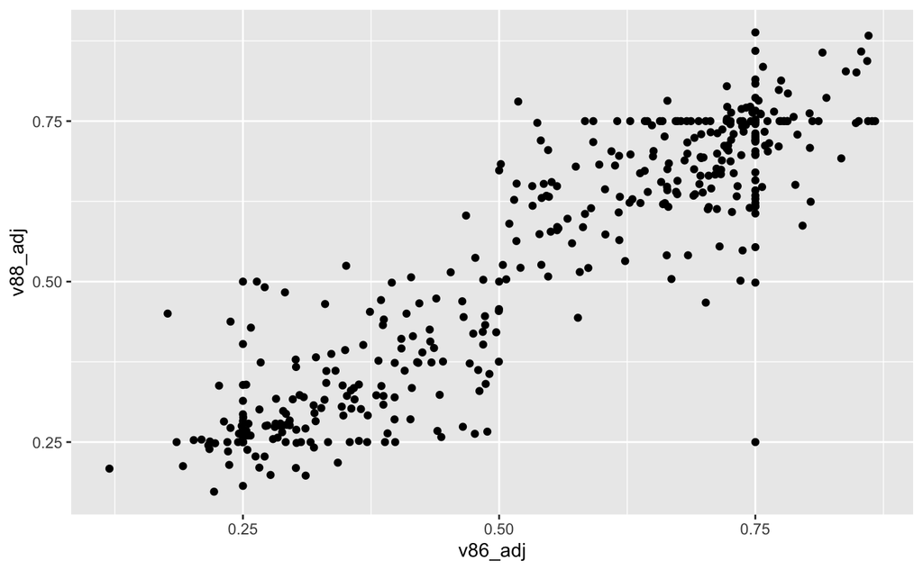

## Fitting the model

```r
print(fit.88, digits = 2)
```

```
stan_glm
 family:       gaussian [identity]
 formula:      vote ~ past_vote + inc
 observations: 435
 predictors:   3
------
            Median MAD_SD
(Intercept) 0.24   0.02
past_vote   0.52   0.03
inc         0.10   0.01

Auxiliary parameter(s):
      Median MAD_SD
sigma 0.07   0.00

------
* For help interpreting the printed output see ?print.stanreg
* For info on the priors used see ?prior_summary.stanreg
```

## Simulation for inferences and predictions of new data points

```r
pred90 <- posterior_predict(fit.88, newdata = data90)
```

[output not shown]

## Predictive simulation for a nonlinear function of new data

```r
sd(dems.pred)
```

```
[1] 2.44729
```

# Mathematical notation and statistical inference